# Oikos_Workshop

Chloe Fouilloux

1/19/2021

Hello and Welcome to Oikos Finland 2021! This will be the first part of our coding workshop, my name is Chloe Fouilloux and I am a 2nd year PhD student at the University of Jyväskylä. Besides data visualization, I like being outside, catching frogs, and writing poetry.

Well, enough about me, let’s jump into this workshop!

## PART 1

First thig first, let’s load some packages. For those who have already done this, you won’t need to do this a second time.

```r
#If this is your first time loading these packages, you have to install them first.
#YOU ONLY HAVE TO INSTALL PACKAGES ONCE.

#First, let's load some packages!
library(ggplot2)
library(ggforce)
library(dplyr)
library(ggsignif)
library(png)
```

Great. so to avoid errors and troubleshooting during our workshop, we have decided to work from data that already exists in base R and doesn’t require any downloading.

```r
#You can actually see all of them by just enting the following:

data()
#These are all the datasets that R automatically provides for you, and is great for practicing!
#Today we will be using two data sets, please load them now:

data("warpbreaks")
data("iris")

#Don't forget the quotation marks!
#You will find the datasets waiting for you under the "Values" column --
#should have something along the lines of <Promise>, click on them,
#and they will be loaded into your working data.
```

Okay, we’ve got our packages, we’ve got our data. ’

First let’s look at our “warpbreaks” data. We’ve got two factors and one numerical variable. This is important to know when we start thinking about how we want to visuliaze data.

Looks like we’re ready to plot!

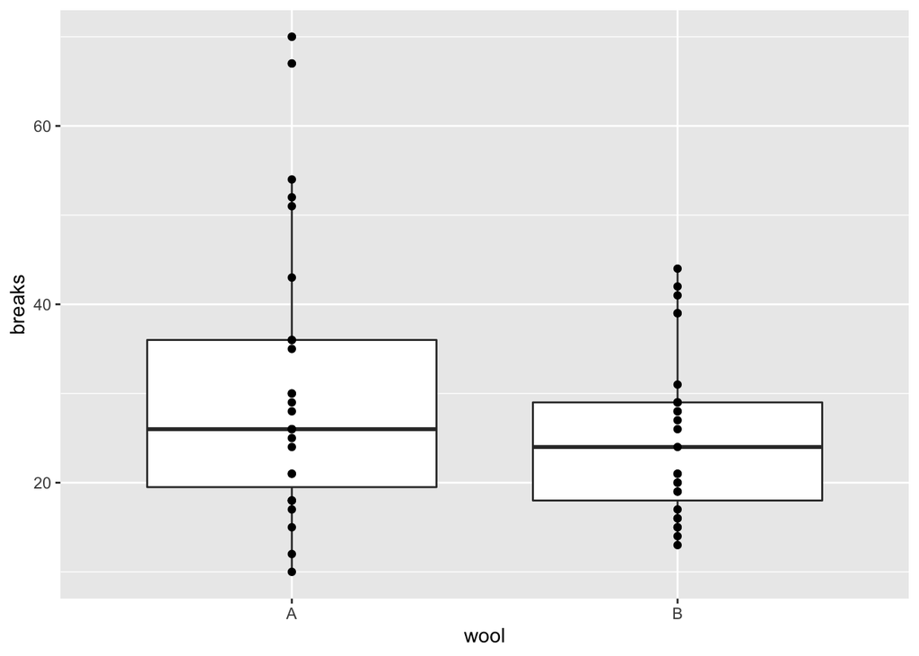

```r
#First, I always like to just look at the data and see what could potentially be interesting to measure.
#This will of course will be more intuitive for you when you know your own data and what questions you have.

#For now, let's look at this wool data. . . who like to knit ? :)

#Alright, let's jump into ggplot.
ggplot(warpbreaks, aes( x = wool, y = breaks))+
  geom_boxplot()+
  geom_point()
```

So, this is a very basic boxplot. What could be improved upon here? Well, the points are hard to distinguish, the plot is kind of bland, and it’s pretty hard to say for sure that anythere of interest is going on. . .